# Completing a randomization tests: gender discrimination

```r
# Load packages
library(ggplot2)
library(tidyverse)
library(infer)

# Load datasets
disc_big = readRDS("./datasets/disc_big.rds")
disc_small = readRDS("./datasets/disc_small.rds")
disc_new = readRDS("./datasets/disc_new.rds")

disc <- data.frame(promote = c(rep("promoted", 35),
                               rep("not_promoted", 13)),
                   sex = c(rep("male", 21), rep("female", 14),
                           rep("male", 3), rep("female", 10)))
```

# Example: gender discrimination

## Gender discrimination hypotheses

$H_0:$ gender and promotion are unrelated variables. $H_A:$: men are more likely to be promoted.

```r
disc
```

| promote | sex |
| --- | --- |
| promoted | male |
| promoted | male |
| promoted | male |
| promoted | male |
| promoted | male |
| promoted | male |
| promoted | male |
| promoted | male |
| promoted | male |
| promoted | male |

[output cut: 38 more lines]

```r
summary(disc)
```

```
   promote              sex
 Length:48          Length:48
 Class :character   Class :character
 Mode  :character   Mode  :character
```

## Summarizing gender discrimination

```r
# Create a contingency table summarizing the data
disc %>%
  # Count the rows by sex, promote
  count(sex, promote)
```

| sex | promote | n |
| --- | --- | --- |
| female | not_promoted | 10 |
| female | promoted | 14 |
| male | not_promoted | 3 |
| male | promoted | 21 |

```r
# Find proportion of each sex who were promoted
disc %>%
  # Group by sex
  group_by(sex) %>%
  # Calculate proportion promoted summary stat
  summarize(promoted_prop = mean(promote == "promoted"))
```

| sex | promoted_prop |
| --- | --- |
| female | 0.5833333 |
| male | 0.8750000 |

Difference in promotions is almost 0.3

## Step-by-step through the permutation

```r
# Replicate the entire data frame, permuting the promote variable
disc_perm <- disc %>%
  specify(promote ~ sex, success = "promoted") %>%
  hypothesize(null = "independence") %>%
  generate(reps = 5, type = "permute")
disc_perm
```

```
Response: promote (factor)
Explanatory: sex (factor)
Null Hypothesis: independence
```

| promote | sex | replicate |
| --- | --- | --- |
| promoted | male | 1 |
| promoted | male | 1 |
| not_promoted | male | 1 |
| promoted | male | 1 |
| promoted | male | 1 |
| promoted | male | 1 |
| promoted | male | 1 |
| promoted | male | 1 |
| promoted | male | 1 |
| promoted | male | 1 |

[output cut: 230 more lines]

```r
disc_perm %>%
  # Group by replicate
  group_by(replicate) %>%
  # Count per group
  count()
```

| replicate | n |
| --- | --- |
| 1 | 48 |
| 2 | 48 |
| 3 | 48 |
| 4 | 48 |
| 5 | 48 |

```r
disc_perm %>%
  # Calculate difference in proportion, male then female
  calculate(stat = "diff in props", order = c("male", "female"))
```

```
Response: promote (factor)
Explanatory: sex (factor)
Null Hypothesis: independence
```

| replicate | stat |
| --- | --- |
| 1 | 0.04166667 |
| 2 | 0.04166667 |
| 3 | -0.04166667 |
| 4 | 0.12500000 |
| 5 | -0.04166667 |

## Randomizing gender discrimination

Recall that we are considering a situation where the number of men and women are fixed (representing the resumes) and the number of people promoted is fixed (the managers were able to promote only 35 individuals).

In this exercise, you’ll create a randomization distribution of the null statistic with 1000 replicates as opposed to just 5 in the previous exercise. As a reminder, the statistic of interest is the difference in proportions promoted between genders (i.e. proportion for males minus proportion for females). From the original dataset, you can calculate how the promotion rates differ between males and females. Using the specify-hypothesis-generate-calculate workflow in infer, you can calculate the same statistic, but instead of getting a single number, you get a whole distribution. In this exercise, you’ll compare that single number from the original dataset to the distribution made by the simulation.

```r
# Calculate the observed difference in promotion rate
diff_orig <- disc %>%
  group_by(sex) %>%
  summarize(prop_prom = mean(promote == "promoted")) %>%
  summarize(stat = diff(prop_prom)) %>%
  pull()

diff_orig
```

```
[1] 0.2916667
```

```r
disc_perm <- disc %>%
  specify(promote ~ sex, success = "promoted") %>%
  hypothesize(null = "independence") %>%
  generate(reps = 1000, type = "permute") %>%
  calculate(stat = "diff in props", order = c("male", "female"))

disc_perm
```

```
Response: promote (factor)
Explanatory: sex (factor)
Null Hypothesis: independence
```

| replicate | stat |
| --- | --- |
| 1 | -0.20833333 |
| 2 | -0.04166667 |
| 3 | -0.12500000 |
| 4 | -0.04166667 |
| 5 | 0.12500000 |
| 6 | 0.04166667 |
| 7 | 0.04166667 |
| 8 | -0.12500000 |
| 9 | -0.04166667 |
| 10 | -0.12500000 |

[output cut: 990 more lines]

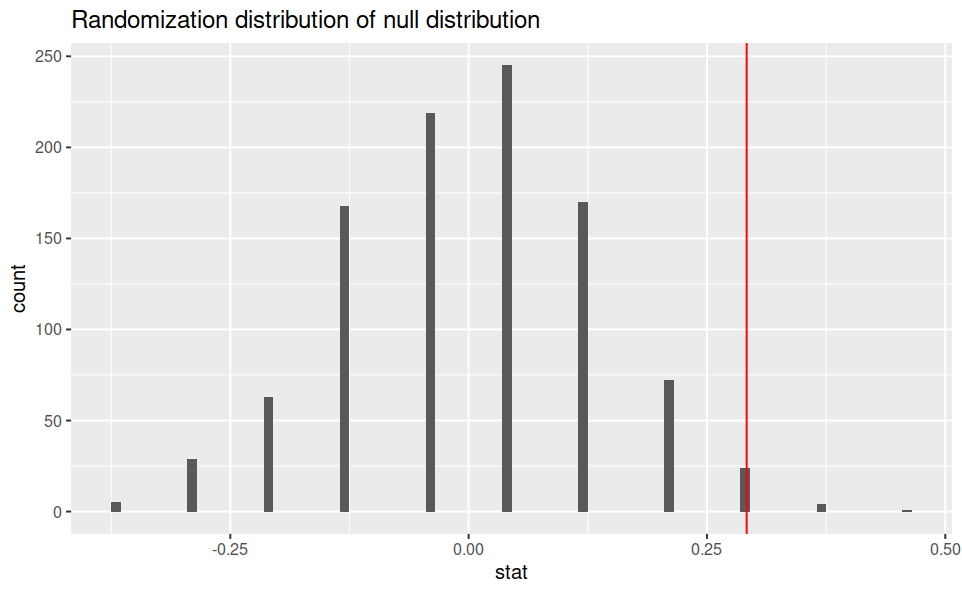

```r
# From previous steps
diff_orig <- disc %>%
  group_by(sex) %>%
  summarize(prop_prom = mean(promote == "promoted")) %>%
  summarize(stat = diff(prop_prom)) %>%
  pull()

disc_perm <- disc %>%
  specify(promote ~ sex, success = "promoted") %>%
  hypothesize(null = "independence") %>%
  generate(reps = 1000, type = "permute") %>%
  calculate(stat = "diff in props", order = c("male", "female"))

ggplot(disc_perm, aes(x = stat)) +
  geom_histogram(binwidth = 0.01) +
  geom_vline(aes(xintercept = diff_orig), color = "red") +
  ggtitle("Randomization distribution of null distribution")
```

In the population there is evidence that women are promoted at a different rate, but we cannot tell whether the difference is due to discrimination or something else.

# Distribution of statistics

It seems as though the statistic—a difference in promotion rates of 0.2917—is on the extreme end of the permutation distribution. That is, there are very few permuted differences which are as extreme as the observed difference.

To quantify the extreme permuted (null) differences, we use the quantile() function.

```r
disc_perm %>%
  summarize(
    q.90 = quantile(stat, p = 0.9),
    q.95 = quantile(stat, p = 0.95),
    q.99 = quantile(stat, p = 0.99)
  ) -> disc_perm_quantiles

disc_perm_quantiles
```

| q.90 | q.95 | q.99 |
| --- | --- | --- |
| 0.2083333 | 0.2083333 | 0.2916667 |

## Critical Region (One Sided)

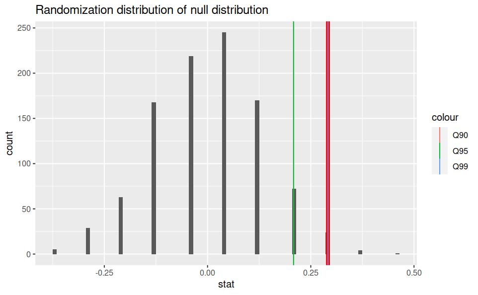

```r
ggplot(disc_perm, aes(x = stat)) +
  geom_histogram(binwidth = 0.01) +

  geom_vline(aes(xintercept = diff_orig), color = "red", size = 2) +

  geom_vline(aes(xintercept = disc_perm_quantiles$q.90, color = "Q90")) +
  geom_vline(aes(xintercept = disc_perm_quantiles$q.95, color = "Q95")) +
  geom_vline(aes(xintercept = disc_perm_quantiles$q.99, color = "Q99")) +

  ggtitle("Randomization distribution of null distribution")
```

## Two-sided critical region

For the discrimination data, the question at hand is whether or not women were promoted less often than men. However, there are often scenarios where the research question centers around a difference without directionality.

For example, you might be interested in whether the rate of promotion for men and women is different. In that case, a difference in proportions of -0.29 is just as “extreme” as a difference of positive 0.29.

If you had seen that women were promoted more often, what would the other side of the distribution of permuted differences look like? That is, what are the smallest (negative) values of the distribution of permuted differences?

```r
# Use disc_perm
disc_perm %>%
  summarize(
    q.01 = quantile(stat, p = 0.01),
    q.05 = quantile(stat, p = 0.05),
    q.10 = quantile(stat, p = 0.1)
  )
```

| q.01 | q.05 | q.10 |
| --- | --- | --- |
| -0.2916667 | -0.2083333 | -0.125 |

Now you’ve seen both the upper and lower values of the permuted statistics. The information will help you know whether the value calculated from the data (the observed statistic) is large or small.

# Why 0.05

## How does sample size affect results

Notice that the observed difference of 0.2917 is in the extreme right tail of the permuted differences. If the sample was ten times larger but the sample statistic was exactly the same (i.e. 0.2917), how would the distribution of permuted differences change? Complete the following sentence.

- Be much farther to the right of the permuted differences (completely off of the distribution), because the statistic would be much farther to the right of the permuted differences, as you’ll see in the next exercise.

## Sample size in randomization distribution

We’ve created two new datasets for you with essentially the same difference in proportions as the original discrimination data. However, one of the datasets (disc_small) is one third the size of the original dataset and the other (disc_big) is 10 times larger than the original dataset.

Additionally, the same permutation code used previously has been run on the small and big datasets to create small and big distributions of permuted differences in promotion rates (disc_small_perm and disc_big_perm, respectively).

In this exercise, you’ll use these two new distributions to get a sense for how the differences vary given widely different sample sizes. In particular, notice the range of variability on the x-axis of each plot.

```r
disc_small %>%
  count(sex, promote)
```

| sex | promote | n |
| --- | --- | --- |
| female | not_promoted | 3 |
| female | promoted | 5 |
| male | not_promoted | 1 |
| male | promoted | 7 |

```r
disc_big %>%
  count(sex, promote)
```

| sex | promote | n |
| --- | --- | --- |
| female | not_promoted | 100 |
| female | promoted | 140 |
| male | not_promoted | 30 |
| male | promoted | 210 |

```r
#small
disc_perm_small <- disc_small %>%
  specify(promote ~ sex, success = "promoted") %>%
  hypothesize(null = "independence") %>%
  generate(reps = 1000, type = "permute") %>%
  calculate(stat = "diff in props", order = c("male", "female"))

diff_orig_small <- disc_small %>%
  group_by(sex) %>%
  summarize(prop_prom = mean(promote == "promoted")) %>%
  summarize(stat = diff(prop_prom)) %>%
  pull()

#big
disc_perm_big <- disc_big %>%
  specify(promote ~ sex, success = "promoted") %>%
  hypothesize(null = "independence") %>%
  generate(reps = 1000, type = "permute") %>%
  calculate(stat = "diff in props", order = c("male", "female"))

diff_orig_big <- disc_big %>%
  group_by(sex) %>%
  summarize(prop_prom = mean(promote == "promoted")) %>%
  summarize(stat = diff(prop_prom)) %>%
  pull()
```

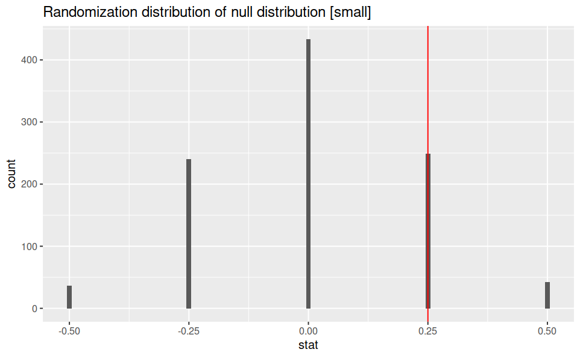

```r
# Using disc_perm_small, plot stat
ggplot(disc_perm_small, aes(x = stat)) +
  # Add a histogram layer with binwidth 0.01
  geom_histogram(binwidth = 0.01) +
  # Add a vline layer, crossing x-axis at diff_orig_small
  geom_vline(aes(xintercept = diff_orig_small), color = "red") +
  ggtitle("Randomization distribution of null distribution [small]")
```

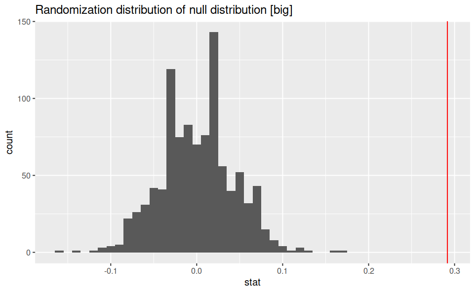

```r
ggplot(disc_perm_big, aes(x = stat)) +
  # Add a histogram layer with binwidth 0.01
  geom_histogram(binwidth = 0.01) +
  # Add a vline layer, crossing x-axis at diff_orig_small
  geom_vline(aes(xintercept = diff_orig_big), color = "red") +
  ggtitle("Randomization distribution of null distribution [big]")
```

The observed difference is consistent with differences you would see by chance if the sample size was small. The observed difference would virtually never be observed by chance if the sample size was big.

## Sample size for critical region

Using the randomization distributions with the small and big datasets, calculate different cutoffs for significance. Remember, you are most interested in a large positive difference in promotion rates, so you are calculating the upper quantiles of 0.90, 0.95, and 0.99.

```r
calc_upper_quantiles <- function(dataset) {
  dataset %>%
    summarize(
      q.90 = quantile(stat, p = 0.90),
      q.95 = quantile(stat, p = 0.95),
      q.99 = quantile(stat, p = 0.99)
    )
}
# Recall the quantiles associated with the original dataset
calc_upper_quantiles(disc_perm)
```

| q.90 | q.95 | q.99 |
| --- | --- | --- |
| 0.2083333 | 0.2083333 | 0.2916667 |

```r
# Calculate the quantiles associated with the small dataset
calc_upper_quantiles(disc_perm_small)
```

| q.90 | q.95 | q.99 |
| --- | --- | --- |
| 0.25 | 0.25 | 0.5 |

```r
# Calculate the quantiles associated with the big dataset
calc_upper_quantiles(disc_perm_big)
```

| q.90 | q.95 | q.99 |
| --- | --- | --- |
| 0.05833333 | 0.075 | 0.1 |

Notice how the differences in proportions must be much larger to be significant if the sample size is small. With a big sample size, a small difference in proportions can be significant.

# What is a p-value?

A p-value is the probability of observing data as or more extreme than what we actually got, given that the null hypothesis is true.

## Calculating the p-value

In the video, you learned that a p-value measures the degree of disagreement between the data and the null hypothesis. Here, you will calculate the p-value for the original discrimination dataset as well as the small and big versions, disc_small and disc_big.

The original differences in proportions are available in your workspace, diff_orig, diff_orig_small, and diff_orig_big, as are the permuted datasets, disc_perm, disc_perm_small, and disc_perm_big.

Recall that you’re only interested in the one-sided hypothesis test here. That is, you’re trying to answer the question, “Are men more likely to be promoted than women?”

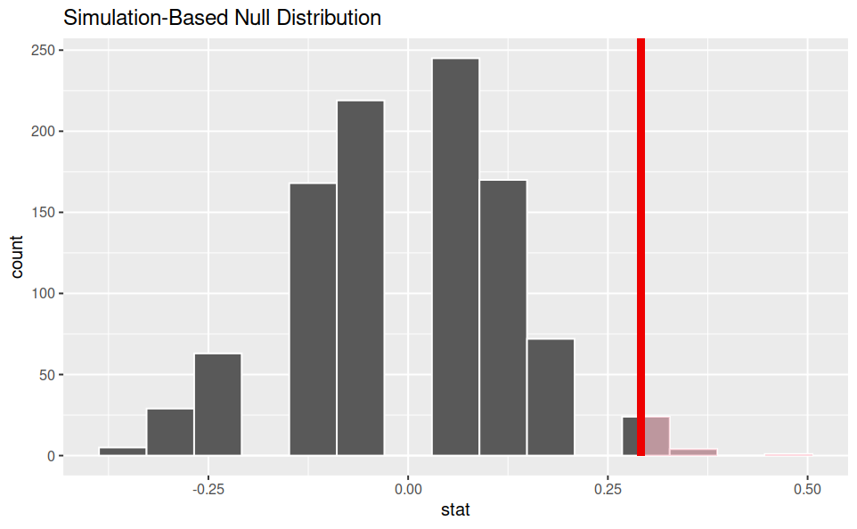

```r
# Visualize and calculate the p-value for the original dataset
disc_perm %>%
  visualize() +
  shade_p_value(obs_stat = diff_orig, direction = "greater")
```

```r
disc_perm %>%
  get_p_value(obs_stat = diff_orig, direction = "greater")
```

| p_value |
| --- |
| 0.029 |

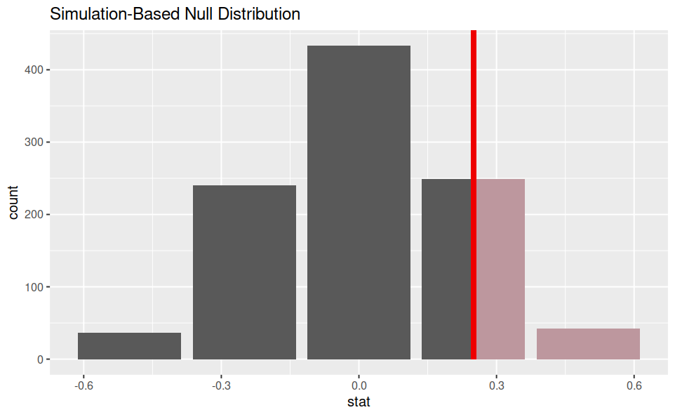

```r
# Visualize and calculate the p-value for the small dataset
disc_perm_small %>%
  visualize() +
  shade_p_value(obs_stat = diff_orig_small, direction = "greater")
```

```r
disc_perm_small %>%
  get_p_value(obs_stat = diff_orig_small, direction = "greater")
```

| p_value |
| --- |
| 0.291 |

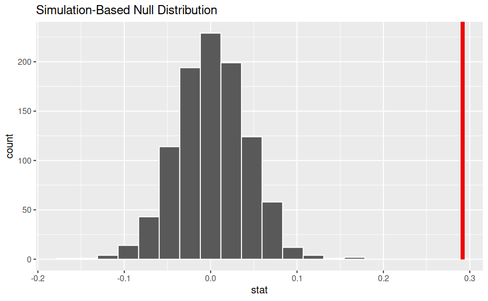

```r
# Visualize and calculate the p-value for the big dataset
disc_perm_big %>%
  visualize() +
  shade_p_value(obs_stat = diff_orig_big, direction = "greater")
```

```r
disc_perm_big %>%
  get_p_value(obs_stat = diff_orig_big, direction = "greater")
```

| p_value |
| --- |
| 0 |

## Practice calculating the p-value

In the original dataset, 87.5% of the men were promoted and 58.3% of the women were promoted.

Consider a situation where there are 24 men, 24 women, and 35 people are still promoted. But in this new scenario, 75% of the men are promoted and 70.8% of the women are promoted. Does the difference in promotion rates still appear to be statistically significant? That is, could this difference in promotion rates have come from random chance?

You’ll analyze these new data, contained in disc_new, using the same permutation algorithm from before.

```r
disc %>%
  count(sex, promote)
```

| sex | promote | n |
| --- | --- | --- |
| female | not_promoted | 10 |
| female | promoted | 14 |
| male | not_promoted | 3 |
| male | promoted | 21 |

```r
disc_new %>%
  count(sex, promote)
```

| sex | promote | n |
| --- | --- | --- |
| female | not_promoted | 7 |
| female | promoted | 17 |
| male | not_promoted | 6 |
| male | promoted | 18 |

```r
disc_perm_new <- disc_new %>%
  specify(promote ~ sex, success = "promoted") %>%
  hypothesize(null = "independence") %>%
  generate(reps = 1000, type = "permute") %>%
  calculate(stat = "diff in props", order = c("male", "female"))

diff_orig_new <- disc_new %>%
  group_by(sex) %>%
  summarize(prop_prom = mean(promote == "promoted")) %>%
  summarize(stat = diff(prop_prom)) %>%
  pull()
```

```r
disc_perm_new
```

```
Response: promote (factor)
Explanatory: sex (factor)
Null Hypothesis: independence
```

| replicate | stat |
| --- | --- |
| 1 | 0.12500000 |
| 2 | 0.12500000 |
| 3 | 0.04166667 |
| 4 | 0.20833333 |
| 5 | -0.20833333 |
| 6 | 0.04166667 |
| 7 | -0.04166667 |
| 8 | 0.37500000 |
| 9 | -0.12500000 |
| 10 | 0.12500000 |

[output cut: 990 more lines]

```r
diff_orig_new
```

```
[1] 0.04166667
```

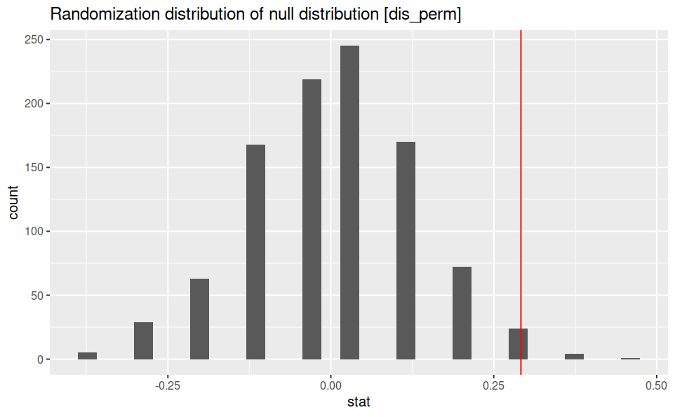

```r
# Recall the distribution of the original permuted differences
ggplot(disc_perm, aes(x = stat)) +
  geom_histogram() +
  geom_vline(aes(xintercept = diff_orig), color = "red") +
  ggtitle("Randomization distribution of null distribution [dis_perm]")
```

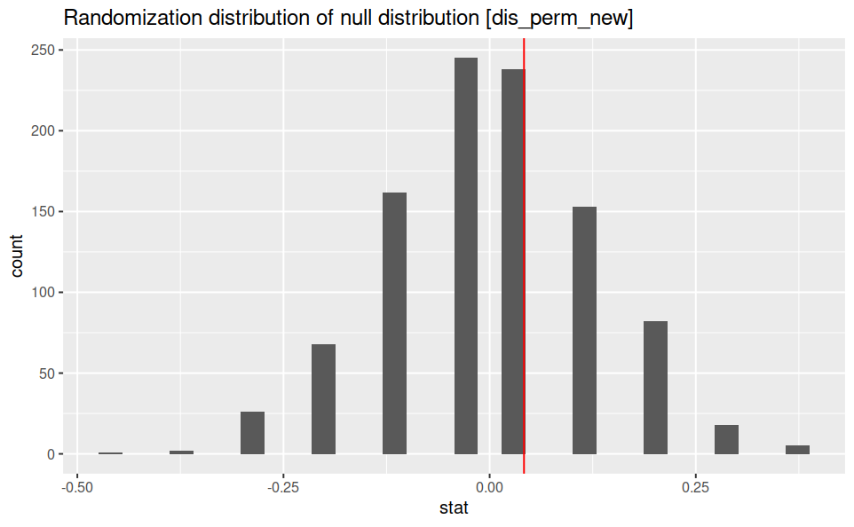

```r
# Plot the distribution of the new permuted differences
ggplot(disc_perm_new, aes(x = stat)) +
  geom_histogram() +
  geom_vline(aes(xintercept = diff_orig_new), color = "red") +
  ggtitle("Randomization distribution of null distribution [dis_perm_new]")
```

```r
# Recall the p-value from the original data
disc_perm %>%
  summarize(p_value = mean(diff_orig <= stat))
```

| p_value |
| --- |
| 0.029 |

```r
# Find the p-value from the new data
disc_perm_new %>%
  summarize(p_value = mean(stat >= diff_orig_new))
```

| p_value |
| --- |
| 0.496 |

Notice that the permutation differences (the two histograms) are essentially the same regardless of whether the original or the new dataset is used.

## Calculating two-sided p-values

What if the original research hypothesis had focused on **any difference** in promotion rates between men and women instead of focusing on whether men are more likely to be promoted than women? In this case, a difference like the one observed would occur twice as often (by chance) because sometimes the difference would be positive and sometimes it would be negative.

When there is no directionality to the alternative hypothesis, the hypothesis and p-value are considered to be two-sided. In a two-sided setting,**the p-value is double the one-sided p-value.**

In this exercise, you’ll calculate a two-sided p-value given the original randomization distribution and dataset.

```r
# Calculate the two-sided p-value
disc_perm %>%
  summarize(p_value = 2 * mean(diff_orig <= stat))
```

| p_value |
| --- |
| 0.058 |

Notice, from the calculation, that the two-sided p-value is twice as big as the one-sided p-value. Often, two-sided p-values are preferred as a way of avoiding making false significance claims.

# Summary of gender discrimination

## Causation

Because the study was randomized, that is, they randomly assigned the resumes to the managers, there is nothing systematically different about the two groups except the name on the resume. As an example, it wouldn’t make sense to have given the female resumes to the first 24 managers who arrived at the training. Those early arriving individuals might be less inclined to promote anyone given their strict adherence to being on time. The only difference in the two groups, both the participants as well as the resumes, was the name on the top of the resume. Therefore, any difference in promotion rates is due to the gender of the applicant. That is, we can infer a causal connection between the gender of the applicant being male and a higher promotion rate.